# Lab Four: Evaluation and Multi-Layer Perceptron

### 1.2.3 Data Visualization

#### correlation matrix

```python
#To plot the distribution of categorical data, we transfer them to numerical data
ddc = df_clean.copy()

brand1 = pd.Series(range(39),index=ddc.brand.unique()).to_dict()
vt1 = pd.Series(range(8),index=ddc.vehicleType.unique()).to_dict()
gear1 = pd.Series(range(2),index=ddc.gearbox.unique()).to_dict()
fuel1 = pd.Series(range(7),index=ddc.fuelType.unique()).to_dict()
model1= pd.Series(range(248),index=ddc.model.unique()).to_dict()
nrd1 = pd.Series(range(3),index=ddc.notRepairedDamage.unique()).to_dict()

ddc['brand'] = ddc['brand'].map(brand1)
ddc['vehicleType'] = ddc['vehicleType'].map(vt1)
ddc['gearbox'] = ddc['gearbox'].map(gear1)
ddc['fuelType'] = ddc['fuelType'].map(fuel1)
ddc['model'] = ddc['model'].map(model1)
ddc['notRepairedDamage'] = ddc['notRepairedDamage'].map(nrd1)
ddc.head()
```

|  | vehicleType | yearOfRegistration | gearbox | powerPS | model | kilometer | fuelType | brand | notRepairedDamage | postalCode | pricerange |
| --- | --- | --- | --- | --- | --- | --- | --- | --- | --- | --- | --- |
| 2 | 0 | 2004 | 0 | 163 | 0 | 125000 | 0 | 0 | 0 | 90480 | 2 |
| 3 | 1 | 2001 | 1 | 75 | 1 | 150000 | 1 | 1 | 1 | 91074 | 0 |
| 4 | 1 | 2008 | 1 | 69 | 2 | 90000 | 0 | 2 | 1 | 60437 | 1 |
| 5 | 2 | 1995 | 1 | 102 | 3 | 150000 | 1 | 3 | 2 | 33775 | 0 |
| 6 | 3 | 2004 | 1 | 109 | 4 | 150000 | 1 | 4 | 1 | 67112 | 1 |

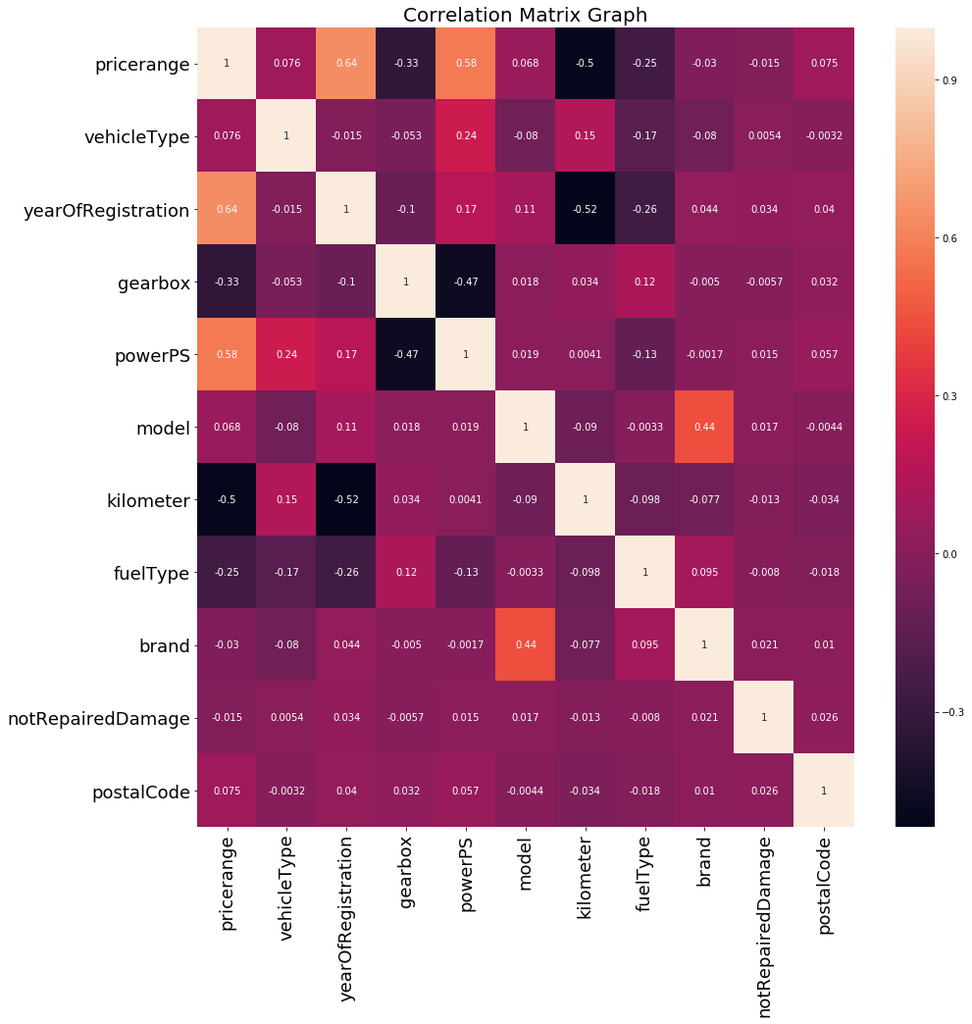

```python
# plot the correlation matrix
vars_to_use = ['pricerange','vehicleType' ,'yearOfRegistration','gearbox','powerPS','model','kilometer','fuelType','brand',
               'notRepairedDamage','postalCode']# pick vars


# fill in the indices

dc = ddc[vars_to_use].corr()
plt.subplots(figsize=(15, 15))
plt.title('Correlation Matrix Graph', fontsize=20)
plt.xticks(fontsize=18)
plt.yticks(fontsize=18)
sns.heatmap(dc,annot=True)
```

We are going to get more information through compare Price range with other variables respectively.

#### Distribution of price range

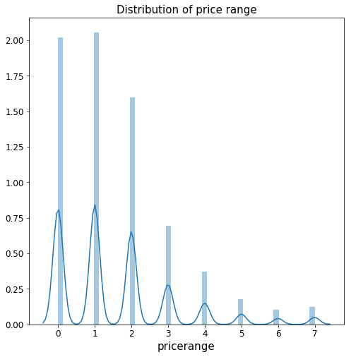

```python
# distribution of price
plt.subplots(figsize=(8, 8))
plt.title('Distribution of price range', fontsize=15)
plt.xlabel('$price range$', fontsize=15, color='black')
plt.xticks(fontsize=12)
plt.yticks(fontsize=12)
sns.distplot(df_clean['pricerange'])
```

#### price range vs year of Registration

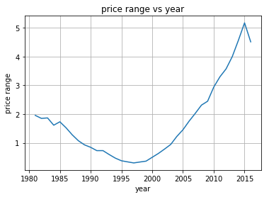

```python
df_ps1 = pd.DataFrame({'y': df_clean['pricerange'], 'x1': df_clean['yearOfRegistration']})
df_ps1.groupby('x1').mean()
#Data for plotting
t = list(df_ps1.groupby('x1').size().keys())
s = list(df_ps1.groupby('x1').mean()['y'])
fig, ax = plt.subplots()
ax.plot(t, s)
ax.set(xlabel='year', ylabel='price range',
       title='price range vs year')
ax.grid()
plt.show()
```

It is clear that from year 1981 to 1997, the price goes down when time goes by. After year 1997,it shows a monotone increasing relationship between price range and year. From the plot we can tell that the year of registration has high influence on the value of a used car, the year of registration more recently, the price more high. Since the used cars registrated after 2015 is not that much, we can't explain why the price range went down after 2015 based on our dataset.

#### Two-Dimensional Distributions of pricerange vs RepairedDamage

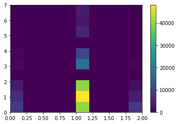

```python
#Two-Dimensional Distributions

plt.hist2d(y=df_clean.pricerange, x=ddc.notRepairedDamage)
plt.colorbar()
plt.show()
```

```python
nrd1
```

```
{'not declare': 0, 'nein': 1, 'ja': 2}
```

'Nein' means true which shows that if the used autos had no repaired damage, their pricerange would be higher. And the car which not declare their damage or have repaired damage before, has lower price range. It correspond to the facts of used car market.

#### price range vs kilometers

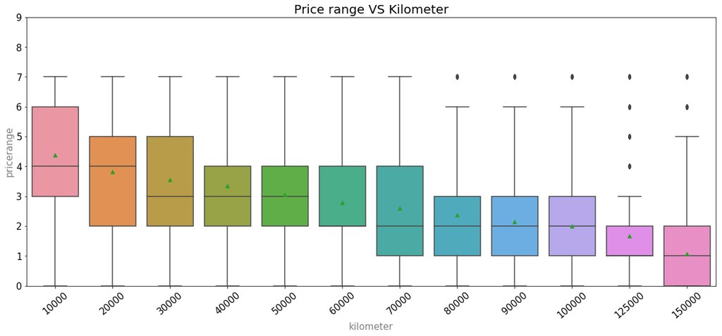

```python
plt.figure(figsize=(20, 8))
plt.xticks(fontsize=15,rotation=40)
plt.yticks(fontsize=15)
plt.ylim((0, 9))
plt.title('Price range VS Kilometer', fontsize=20)
plt.xlabel('$kilometer$', fontsize=15, color='gray')
plt.ylabel('$Price range$', fontsize=15, color='gray')
sns.boxplot(x='kilometer', y='pricerange', data=df_clean, sym='r*', meanline=False, showmeans=True)
```

Through the bar plot we can tell that when the used car has more kilometer, its price will go down. The car which has Less kilometers has more value. The kilometer do affect the price range. However, we can also saw that there are few cars have really high value although the kilometers of them are really high, this maybe caused by the car's type and it's brand, or mistake information.

#### Price Range VS Brand

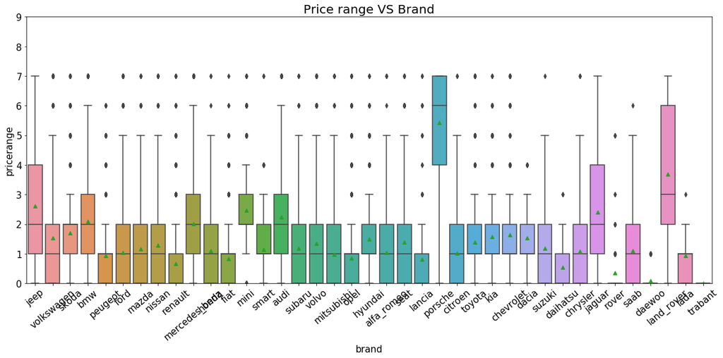

```python
plt.figure(figsize=(20, 8))
plt.xticks(fontsize=15,rotation=40)
plt.yticks(fontsize=15)
plt.ylim((0, 9))
plt.title('Price range VS Brand', fontsize=20)
plt.xlabel('$Brand$', fontsize=15, color='black')
plt.ylabel('$Price Range$', fontsize=15, color='black')
sns.boxplot(x='brand', y='pricerange', data=df_clean, sym='r*', meanline=False, showmeans=True)
```

We can see that the brand porsche is the most expensive price range, and the brand land_rover is the second most expensive . Most used autos' price range is between 0-15000. From this boxplot, we can tell that the brand do have some influence on the value of car, but not that much. Because most of brand of used car's value ranges are still around 0-10000, just few brands over 20000. The few really high values may caused by the type mistake when sallers input the information.

#### price range vs vehicleType

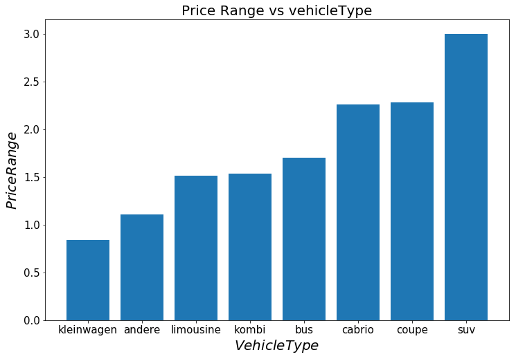

```python
df_groupby_vehicleType = df_clean.groupby(by=['vehicleType'])['pricerange'].mean().sort_values()
r = range(len(df_clean['vehicleType'].unique()))
plt.figure(figsize=(12, 8))
plt.bar(r, df_groupby_vehicleType)
plt.yticks(fontsize=15)
plt.xticks(r, df_groupby_vehicleType.index, fontsize=15)
plt.title('Price Range vs vehicleType', fontsize=20)
plt.ylabel('$Price Range$', fontsize=20, color='black')
plt.xlabel('$VehicleType$', fontsize=20, color='black')
plt.show()
```

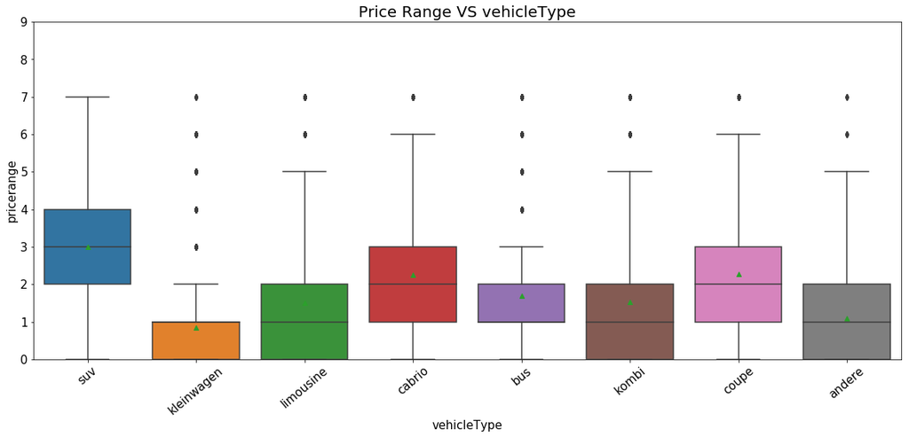

```python
plt.figure(figsize=(20, 8))
plt.xticks(fontsize=15,rotation=40)
plt.yticks(fontsize=15)
plt.ylim((0, 9))
plt.title('Price Range VS vehicleType', fontsize=20)
plt.xlabel('$vehicletype$', fontsize=15, color='black')
plt.ylabel('$Price Range$', fontsize=15, color='black')
sns.boxplot(x='vehicleType', y='pricerange', data=df_clean, sym='r*', meanline=False, showmeans=True)
```

From the relationship from price and vehicletype, the SUVs seems like have most values than other type, that make sense, because new SUVs also have high price in market, and SUV always has a high depreciation rate. Kleinwagen, limousine, bus , kombi and andere have the most common value range around 0-15000. Since cabrio and coupe also have high market turnover, their depreciation also not low, that means they will get a better value in the used car market. So we can see that the vehicle type do affect the used car's value.

#### price range vs gearbox

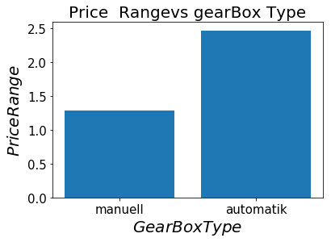

```python
df_groupby_gearbox = df_clean.groupby(by=['gearbox'])['pricerange'].mean().sort_values()
r = range(len(df_clean['gearbox'].unique()))

plt.figure(figsize=(6, 4))
plt.bar(r, df_groupby_gearbox)
plt.yticks(fontsize=15)
plt.xticks(r, df_groupby_gearbox.index, fontsize=15)
plt.title('Price  Rangevs gearBox Type', fontsize=20)
plt.ylabel('$Price Range$', fontsize=20, color='black')
plt.xlabel('$GearBox Type$', fontsize=20, color='black')
plt.show()
```

According to the plot, the price of the automatik ones are higher than the manuell ones because manuell ones are much more fuel efficent.There were enough of them being sold and driven that selling and re-sale value were not a problem for the manuell ones.

#### price range vs fueltype

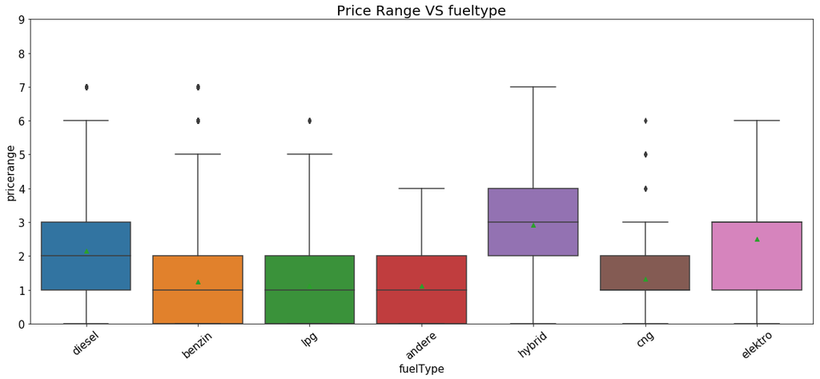

```python
plt.figure(figsize=(20, 8))
plt.xticks(fontsize=15,rotation=40)
plt.yticks(fontsize=15)
plt.ylim((0, 9))
plt.title('Price Range VS fueltype', fontsize=20)
plt.xlabel('$fueltype$', fontsize=15, color='black')
plt.ylabel('$Price Range$', fontsize=15, color='black')
sns.boxplot(x='fuelType', y='pricerange', data=df_clean, sym='r*', meanline=False, showmeans=True)
```

It seems that the hybrid ones are have higher values because of advanced technology which is within hybrids, and it also help people save money through use less gasoline. And there are not that much different about the other types. We can tell that fuel types do affect the value of a used car, but the influence is not that big.

# 2.Evaluation

## 2.1 Matrix Selection

```python
df_clean.pricerange.value_counts().to_frame()
```

|  | pricerange |
| --- | --- |
| 1 | 58206 |
| 0 | 57161 |
| 2 | 45210 |
| 3 | 19703 |
| 4 | 10484 |
| 5 | 4994 |
| 7 | 3458 |
| 6 | 2896 |

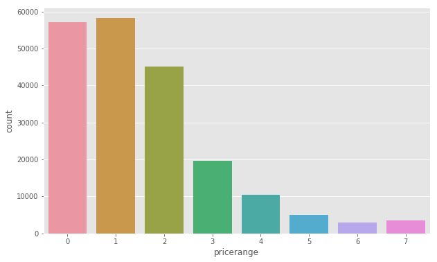

```python
plt.style.use('ggplot')
plt.figure(figsize=(10, 6))
sns.countplot(df_clean['pricerange'])
```

```python
from sklearn.model_selection import train_test_split
x = ddc.drop(labels=["pricerange"], axis="columns")
y = ddc.pricerange.values
x_train, x_test, y_train, y_test = train_test_split(x, y, test_size=0.20, random_state=1)
label=list(set(y.astype(str)))
```

```python
y
```

```
array([2, 0, 1, ..., 2, 1, 6])
```

```python
from sklearn.preprocessing import StandardScaler
from sklearn.linear_model import LogisticRegression
from sklearn.pipeline import Pipeline
from sklearn.metrics import classification_report

pipe_lr = Pipeline([('scl', StandardScaler()),
                    ('clf', LogisticRegression(class_weight='balanced', random_state=1))])

pipe_lr.fit(x_train, y_train)
y_pred = pipe_lr.predict(x_test)
print(classification_report(y_test, y_pred, target_names=label))
```

```
              precision    recall  f1-score   support

           2       0.68      0.86      0.76     11428
           5       0.62      0.45      0.52     11694
           6       0.60      0.61      0.61      9117
           0       0.46      0.37      0.41      3827
           3       0.36      0.38      0.37      2097
           1       0.31      0.28      0.29      1013
           7       0.24      0.21      0.22       577
           4       0.23      0.51      0.32       670

   micro avg       0.58      0.58      0.58     40423
   macro avg       0.44      0.46      0.44     40423
weighted avg       0.58      0.58      0.58     40423
```

From the countplot shown above, it is clear that the numbers between each pricerange are unbalanced.Pricerange 1 has the most numbers and pricerange 6 has the least numbers.After comparing with different measure models, we decided to use F1 score.Because F1 score is good at evaluating uneven cases.

F1 scores has macro average and micro average methods.A macro-average will compute the metric independently for each class and then take the average (hence treating all classes equally), whereas a micro-average will aggregate the contributions of all classes to compute the average metric. For our case, it was apparently not equally distributed, so we chose the micro-average method. And from the classification report, we can see that the micro-average methods have higher precision than the macro-average method.

```python
from sklearn.metrics import make_scorer,f1_score

# make f1 micro our score
#score = make_scorer(f1_score, average='micro', pos_label=1, greater_is_better = True)
score1 = make_scorer(score_func=f1_score,
                          pos_label=1,
                          greater_is_better=True,
                          average='micro')
```

## 2.2 Data Spliting Selection

We are considering about two methods: k-fold cross validation and stratified k-fold cross validation.No matter which k-fold cross validation method, the process repeats k times and all observations are used for training and validation. So we will get more information, which means more precision and higher F1 score.

```python
from sklearn.model_selection import KFold

x_train = pd.DataFrame(x_train)
y_train = pd.DataFrame(y_train)
kfold = KFold(n_splits=10,random_state=1).split(x_train, y_train)

scores = []
for k, (train, test) in enumerate(kfold):
    pipe_lr.fit(x_train.iloc[train], y_train.iloc[train])
    score = pipe_lr.score(x_train.iloc[test], y_train.iloc[test])
    scores.append(score)
    print('Fold: %s, Acc: %.3f' % (k+1, score))

print('\nCV accuracy: %.3f +/- %.3f' % (np.mean(scores), np.std(scores)))
```

```
Fold: 1, Acc: 0.584
Fold: 2, Acc: 0.585
Fold: 3, Acc: 0.584
Fold: 4, Acc: 0.583
Fold: 5, Acc: 0.587
Fold: 6, Acc: 0.585
Fold: 7, Acc: 0.583
Fold: 8, Acc: 0.584
Fold: 9, Acc: 0.584
Fold: 10, Acc: 0.584

CV accuracy: 0.584 +/- 0.001
```

```python
from sklearn.model_selection import StratifiedKFold

x_train = pd.DataFrame(x_train)
y_train = pd.DataFrame(y_train)
kfold = StratifiedKFold(n_splits=10,random_state=1).split(x_train, y_train)

scores = []
for k, (train, test) in enumerate(kfold):
    pipe_lr.fit(x_train.iloc[train], y_train.iloc[train])
    score = pipe_lr.score(x_train.iloc[test], y_train.iloc[test])
    scores.append(score)
    print('Fold: %s, Acc: %.3f' % (k+1, score))

print('\nCV accuracy: %.3f +/- %.3f' % (np.mean(scores), np.std(scores)))
```

```
Fold: 1, Acc: 0.586
Fold: 2, Acc: 0.583
Fold: 3, Acc: 0.584
Fold: 4, Acc: 0.581
Fold: 5, Acc: 0.588
Fold: 6, Acc: 0.581
Fold: 7, Acc: 0.583
Fold: 8, Acc: 0.586
Fold: 9, Acc: 0.583
Fold: 10, Acc: 0.585

CV accuracy: 0.584 +/- 0.002
```

```python
from sklearn.model_selection import cross_val_score

scores = cross_val_score(estimator=pipe_lr,
                         X=x_train,
                         y=y_train,
                         cv=10,
                         n_jobs=-1)
print('CV accuracy scores: %s' % scores)
print('CV accuracy: %.3f +/- %.3f' % (np.mean(scores), np.std(scores)))
```

```
CV accuracy scores: [0.58610029 0.58329211 0.58431761 0.58148308 0.58760591 0.58142124
 0.58337457 0.58582297 0.58289002 0.58496752]
CV accuracy: 0.584 +/- 0.002
```

The accuracy looks similar but Stratified k-fold cross validation is preferable in the uneven cases. And a value of k=10 is very recommended in the field of applied machine learning, so we chose the stratified 10-fold cross validation.

```
(0.40540516473731075, 0.42704467864034434)
```

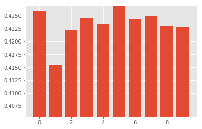

```python
#select cross validation
from sklearn.model_selection import cross_val_score
from sklearn.model_selection import StratifiedKFold
from sklearn.pipeline import Pipeline
from sklearn.linear_model import LogisticRegression

clf = Pipeline([('clf',LogisticRegression(random_state=49450))])

#x = ddc.drop(labels=["pricerange"], axis="columns")
#x = x.astype(np.float64).values
#y = ddc.pricerange.values
cv = StratifiedKFold(n_splits=10)
criteria = cross_val_score(estimator=clf,X=x,
                                    y=y,
                                    cv=cv,
                                    scoring=score1)

plt.bar(range(len(criteria)),criteria)
plt.ylim([min(criteria)-0.01,max(criteria)])
```

The accuracy is not so great, but it is acceptable.

# 3.Modeling

## 3.1 Implementation of the Multi-Layer Perceptron

We implemented the multi-layer perceptron based on the instructor's template code. To store all weight matrices for the multi-layer perceptron, we use a list W and do a for-loop to store all weight matrices. To implement the multi-layer perceptron, besides the _initialize__weights function, we also modified following functions: _L2 _reg, _cost, _feedforward, _get _gradient, predict, and fit. In addition, we added following functions: _phi _function, _forward _grad, _cost _grad, get _params, and set _params.

```python
import numpy as np
from scipy.special import expit
import sys
import pandas as pd

# start with a simple base classifier, which can't be fit or predicted
# it only has internal classes to be used by classes that will subclass it
class MultiLayerPerceptronBase(object):
    def __init__(self, n_hidden=30, n_layers=1,
                 C=0.0, epochs=500, eta=0.001, random_state=None,
                 phi='sigmoid', cost='cross_entropy'):
        np.random.seed(random_state)
        self.n_hidden = n_hidden   # number of hidden units
        self.n_layers = n_layers   # number of hidden layers
        self.l2_C = C
        self.epochs = epochs
        self.eta = eta

        if phi in ['sigmoid', 'linear']:
            self.phi = phi
        else:
            raise ValueError('Invalid! This phi function has not yet been implemented.')

        if cost in ['quadratic', 'cross_entropy']:
            self.cost = cost
        else:
            raise ValueError('Invalid! This cost function has not yet been implemented.')

    @staticmethod
    def _encode_labels(y):
        """Encode labels into one-hot representation"""
        onehot = pd.get_dummies(y).values.T

        return onehot

    # Modified for multi-layer
    def _initialize_weights(self):
        """Initialize weights with small random numbers."""
        W = []

        bound = np.sqrt(6. / (self.n_hidden + self.n_features_ + 1))
        W_first = np.random.uniform(-bound, bound, (self.n_hidden, self.n_features_ + 1))
        W.append(W_first)

        for i in range(1, self.n_layers):
            bound = np.sqrt(6. / (self.n_hidden + self.n_hidden + 1))
            W_i = np.random.uniform(-bound, bound, (self.n_hidden, self.n_hidden + 1))
            W.append(W_i)

        bound = np.sqrt(0.5 / (self.n_hidden + self.n_output_ + 1))
        W_last = np.random.uniform(-bound, bound, (self.n_output_, self.n_hidden + 1))
        W.append(W_last)

        return W

    def _phi_function(self, z):
        if self.phi == 'sigmoid':         # implement sigmoid function
            """Use scipy.special.expit to avoid overflow"""
            # 1.0 / (1.0 + np.exp(-z))
            return expit(z)
        elif self.phi == 'linear':        # implement linear function
            return z

    @staticmethod
    def _add_bias_unit(X, how='column'):
        """Add bias unit (column or row of 1s) to array at index 0"""
        if how == 'column':
            ones = np.ones((X.shape[0], 1))
            X_new = np.hstack((ones, X))
        elif how == 'row':
            ones = np.ones((1, X.shape[1]))
            X_new = np.vstack((ones, X))
        return X_new

    # Modified for multi-layer
    @staticmethod
    def _L2_reg(lambda_, W):
        """Compute L2-regularization cost"""
        # only compute for non-bias terms
        result = 0
        for i in range(len(W)):
            result = result + np.mean(W[i][:, 1:] ** 2)
        return (lambda_/2.0) * np.sqrt(result)
        #return (lambda_/2.0) * np.sqrt(np.mean(W1[:, 1:] ** 2) + np.mean(W2[:, 1:] ** 2))

    # Modified for multi-layer
    def _cost(self, A, Y_enc, W):
        '''Get the objective function value'''
        if self.cost == 'quadratic':
            cost = np.mean((Y_enc - A) ** 2)
        elif self.cost == 'cross_entropy':
            cost = -np.mean(np.nan_to_num(Y_enc * np.log(A) + (1 - Y_enc) * np.log(1 - A)))

        L2_term = self._L2_reg(self.l2_C, W)
        return cost + L2_term
```

```python
class MultiLayerPerceptron(MultiLayerPerceptronBase):
    def _feedforward(self, X, W):
        """Compute feedforward step
        -----------
        X : Input layer with original features.
        W[0]: Weight matrix for input layer -> hidden layer.
        W[i]: Weight matrix for (i)th hidden layer -> (i+1)th hidden layer
        W[self.n_layers]: Weight matrix for hidden layer -> output layer.
        ----------
        A : activations into layer (or output layer)
        Z : layer inputs

        """
        A_list = []
        Z_list = []

        A = self._add_bias_unit(X, how='column').T
        A_list.append(A)

        for i in range(self.n_layers):
            Z = W[i] @ A
            A = self._add_bias_unit(self._phi_function(Z), how='row')
            Z_list.append(Z)
            A_list.append(A)

        Z = W[self.n_layers] @ A
        A = self._phi_function(Z)
        Z_list.append(Z)
        A_list.append(A)

        return A_list, Z_list   # len(A_list) = len(Z_list) + 1

    def _forward_grad(self, A):
        if self.phi == 'sigmoid':
            return A * (1 - A)
        elif self.phi == 'linear':
            return np.ones(A.shape)

    def _cost_grad(self, A, Y):
        if self.cost == 'quadratic':
            return -2 * (Y - A) * self._forward_grad(A)
        elif self.cost == 'cross_entropy':
            return (A - Y)

    def _get_gradient(self, A_list, Z_list, Y_enc, W):
        """Compute gradient step using backpropagation"""
        # vectorized backpropagation
        grad_list = W.copy()
        V = W.copy()

        V[-1] = self._cost_grad(A_list[-1], Y_enc)

        grad_list[-1] = V[-1] @ A_list[-2].T
        grad_list[-1][:,1:] += W[-1][:,1:] * self.l2_C

        # for each instance's activations
        for i in range(-2, -self.n_layers-2, -1):
            if i == -2:
                V[i] = (self._forward_grad(A_list[i]) * (W[i+1].T @ V[i+1]))
            else:
                V[i] = (self._forward_grad(A_list[i]) * (W[i+1].T @ V[i+1][1:,:]))

            grad_list[i] = V[i][1:,:] @ A_list[i-1].T

            # regularize weights that are not bias terms
            grad_list[i][:,1:] += W[i][:,1:] * self.l2_C

        return grad_list

    def predict(self, X):
        """Predict class labels"""
        A_list, _ = self._feedforward(X, self.W)
        y_pred = np.argmax(A_list[-1], axis=0)
        return y_pred

    def fit(self, X, y, print_progress=False):
        """Learn weights from training data"""

        X_data, y_data = X.copy(), y.copy()
        Y_enc = self._encode_labels(y)

        # init weights and setup matrices
        self.n_features_ = X_data.shape[1]
        self.n_output_ = Y_enc.shape[0]
        self.W = self._initialize_weights()

        self.cost_ = []
        self.gradients_ = []

        for i in range(len(self.W)):
            self.gradients_.append([])

        for i in range(self.epochs):

            if print_progress > 0 and (i + 1) % print_progress == 0:
                sys.stderr.write('\rEpoch: %d/%d' % (i + 1, self.epochs))
                sys.stderr.flush()

            # feedforward all instances
            A_list, Z_list = self._feedforward(X_data, self.W)

            cost = self._cost(A_list[-1], Y_enc, self.W)
            self.cost_.append(cost)

            # compute gradient via backpropagation
            grad_list = self._get_gradient(A_list, Z_list, Y_enc, self.W)

            for j in range(len(self.W)):
                self.W[j] -= self.eta * grad_list[j]
                self.gradients_[j].append(abs(np.mean(grad_list[j])))

        return self

    # make the estimator compliant with sklearn's API
    def get_params(self, deep=True):
        return {'n_hidden': self.n_hidden,
                'n_layers': self.n_layers,
                'C': self.l2_C,
                'epochs': self.epochs,
                'eta': self.eta,
                'phi': self.phi,
                'cost': self.cost
               }

    def set_params(self, **parameters):
        for parameter, value in parameters.items():
            self.__setattr__(parameter, value)
        return self
```

### Testing the Perceptron

Now we have the code for the multi-layer perceptron, so we need to check to make sure it actually works. We will test each cost function/activation function combination on the iris dataset to make sure they all at least learn.

```python
from sklearn.datasets import load_iris
iris = load_iris()
```

```python
params = dict(n_hidden=100,
              n_layers=2,
              C=0.1, # tradeoff L2 regularizer
              epochs=500, # iterations
              eta=0.001,  # learning rate
              random_state=1
             )
```

```python
from sklearn.preprocessing import StandardScaler

iris_data = StandardScaler().fit_transform(iris.data)
```

#### Quadratic & Sigmoid

```python
%%time
nn = MultiLayerPerceptron(**params, phi='sigmoid', cost='quadratic')
nn.fit(iris_data, iris.target, print_progress=10)
yhat = nn.predict(iris_data)
print('Test acc:',f1_score(iris.target, yhat, average='micro'))
```

```
Epoch: 500/500
```

```
Test acc: 0.88
CPU times: user 1.85 s, sys: 38.2 ms, total: 1.89 s
Wall time: 983 ms
```

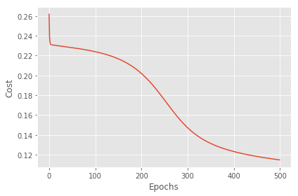

```python
plt.plot(range(len(nn.cost_)), nn.cost_)
plt.ylabel('Cost')
plt.xlabel('Epochs')
plt.tight_layout()
plt.show()
```

#### Quadratic & Linear

```python
%%time
nn = MultiLayerPerceptron(**params, phi='linear', cost='quadratic')
nn.fit(iris_data, iris.target, print_progress=10)
yhat = nn.predict(iris_data)
print('Test acc:',f1_score(iris.target, yhat, average='micro'))
```

```
Epoch: 500/500
```

```
Test acc: 0.8466666666666667
CPU times: user 1.36 s, sys: 32.1 ms, total: 1.39 s
Wall time: 725 ms
```

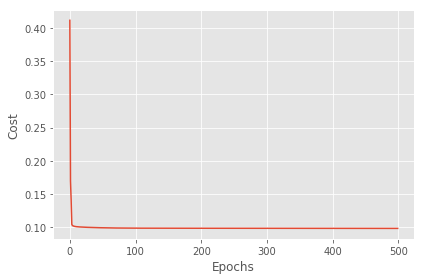

```python
plt.plot(range(len(nn.cost_)), nn.cost_)
plt.ylabel('Cost')
plt.xlabel('Epochs')
plt.tight_layout()
plt.show()
```

#### Cross Entropy & Sigmoid

```python
%%time
nn = MultiLayerPerceptron(**params, phi='sigmoid', cost='cross_entropy')
nn.fit(iris_data, iris.target, print_progress=10)
yhat = nn.predict(iris_data)
print('Test acc:',f1_score(iris.target, yhat, average='micro'))
```

```
Epoch: 500/500
```

```
Test acc: 0.9666666666666667
CPU times: user 1.93 s, sys: 36 ms, total: 1.97 s
Wall time: 1.02 s
```

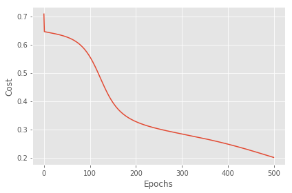

```python
plt.plot(range(len(nn.cost_)), nn.cost_)
plt.ylabel('Cost')
plt.xlabel('Epochs')
plt.tight_layout()
plt.show()
```

#### Cross Entropy & Linear

```python
%%time
nn = MultiLayerPerceptron(**params, phi='linear', cost='cross_entropy')
nn.fit(iris_data, iris.target, print_progress=10)
yhat = nn.predict(iris_data)
print('Test acc:',f1_score(iris.target, yhat, average='micro'))
```

```
Epoch: 500/500
```

```
Test acc: 0.8466666666666667
CPU times: user 1.52 s, sys: 40.3 ms, total: 1.56 s
Wall time: 800 ms
```

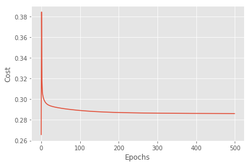

```python
plt.plot(range(len(nn.cost_)), nn.cost_)
plt.ylabel('Cost')
plt.xlabel('Epochs')
plt.tight_layout()
plt.show()
```

It looks good. We will now proceed to the analysis on our actual data.

## 3.2 Tuning the Hyper-Parameters

### 3.2.1 Tuning Phi Function and Objective Function

```python
params = dict(n_hidden=10,
              n_layers=3,
              C=0.01, # tradeoff L2 regularizer
              epochs=100, # iterations
              eta=0.001,  # learning rate
              random_state=1
             )
```

```python
# select cross validation
cv = StratifiedKFold(n_splits=5)
# select evaluation criteria
score = make_scorer(score_func=f1_score,
                    pos_label=1,
                    greater_is_better=True,
                    average='micro')

X = ddc.drop(labels=["pricerange"], axis="columns")
y = ddc.pricerange.values
```

#### Quadratic & Sigmoid

```python
%%time
# select model
nn = MultiLayerPerceptron(**params, phi='sigmoid', cost='quadratic')

# run model training and cross validation
per_fold_eval_criteria = cross_val_score(estimator=nn,
                                         X=X,
                                         y=y,
                                         cv=cv,
                                         scoring=score
                                        )
```

```
CPU times: user 2min 59s, sys: 13.7 s, total: 3min 12s
Wall time: 1min 44s
```

```python
for a in per_fold_eval_criteria:
    print(a)
print("\nMean:", np.mean(per_fold_eval_criteria))
```

```
0.2879829812496908
0.2828092917398511
0.2879796155653959
0.2879938645753445
0.28800811499542295

Mean: 0.2869547736251411
```

```
(0.2728092917398511, 0.28800811499542295)
```

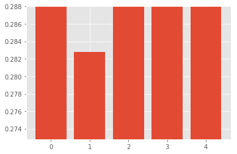

```python
plt.bar(range(len(per_fold_eval_criteria)),per_fold_eval_criteria)
plt.ylim([min(per_fold_eval_criteria)-0.01,max(per_fold_eval_criteria)])
```

#### Quadratic & Linear

```python
%%time
# select model
nn = MultiLayerPerceptron(**params, phi='linear', cost='quadratic')

# run model training and cross validation
per_fold_eval_criteria = cross_val_score(estimator=nn,
                                         X=X,
                                         y=y,
                                         cv=cv,
                                         scoring=score
                                        )
```

```
CPU times: user 1min 43s, sys: 11.3 s, total: 1min 54s
Wall time: 1min 3s
```

```python
for a in per_fold_eval_criteria:
    print(a)
print("\nMean:", np.mean(per_fold_eval_criteria))
```

```
0.28281304111215555
0.2828092917398511
0.2828092917398511
0.2828232849261523
0.2828372794972661

Mean: 0.2828184378030552
```

```python
plt.bar(range(len(per_fold_eval_criteria)),per_fold_eval_criteria)
plt.ylim([min(per_fold_eval_criteria)-0.01,max(per_fold_eval_criteria)])
```

[output not shown]

```
(0.2728092917398511, 0.2828372794972661)
```

#### Cross Entropy & Sigmoid

```python
%%time
# select model
nn = MultiLayerPerceptron(**params, phi='sigmoid', cost='cross_entropy')

# run model training and cross validation
per_fold_eval_criteria = cross_val_score(estimator=nn,
                                         X=X,
                                         y=y,
                                         cv=cv,
                                         scoring=score
                                        )
```

```
CPU times: user 3min 33s, sys: 15.1 s, total: 3min 48s
Wall time: 2min 5s
```

```python
for a in per_fold_eval_criteria:
    print(a)
print("\nMean:", np.mean(per_fold_eval_criteria))
```

```
0.09748676594271014
0.09749400094005888
0.2879796155653959
0.2828232849261523
0.28800811499542295

Mean: 0.21075835647394806
```

```
(0.08748676594271014, 0.28800811499542295)
```

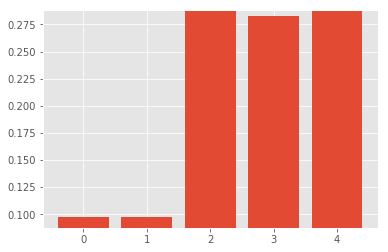

```python
plt.bar(range(len(per_fold_eval_criteria)),per_fold_eval_criteria)
plt.ylim([min(per_fold_eval_criteria)-0.01,max(per_fold_eval_criteria)])
```

#### Cross Entropy & Linear

```python
%%time
# select model
nn = MultiLayerPerceptron(**params, phi='linear', cost='cross_entropy')

# run model training and cross validation
per_fold_eval_criteria = cross_val_score(estimator=nn,
                                         X=X,
                                         y=y,
                                         cv=cv,
                                         scoring=score
                                        )
```

```
CPU times: user 2min 15s, sys: 11.8 s, total: 2min 27s
Wall time: 1min 20s
```

```python
for a in per_fold_eval_criteria:
    print(a)
print("\nMean:", np.mean(per_fold_eval_criteria))
```

```
0.28281304111215555
0.2828092917398511
0.2828092917398511
0.2828232849261523
0.2828372794972661

Mean: 0.2828184378030552
```

```python
plt.bar(range(len(per_fold_eval_criteria)),per_fold_eval_criteria)
plt.ylim([min(per_fold_eval_criteria)-0.01,max(per_fold_eval_criteria)])
```

[output not shown]

```
(0.2728092917398511, 0.2828372794972661)
```

According to the results above, choosing sigmoid as phi function and quadratic as objective function gives us a relatively better result.

### 3.2.2 Tuning Number of Layers

We will choose sigmoid as phi function and quadratic as objective function when tuning numbers of hidden layers. </br> To tune the number of hidden layers, we will choose three more different numbers of n_layers to see their results.

```python
params = dict(n_hidden=10,
              C=0.01, # tradeoff L2 regularizer
              epochs=100, # iterations
              eta=0.001,  # learning rate
              random_state=1,
              phi='sigmoid',
              cost='quadratic'
             )
```

### n_layers = 2

```python
%%time
# select model
nn = MultiLayerPerceptron(**params, n_layers=2)

# run model training and cross validation
per_fold_eval_criteria = cross_val_score(estimator=nn,
                                         X=X,
                                         y=y,
                                         cv=cv,
                                         scoring=score
                                        )
```

```
CPU times: user 1min 56s, sys: 8.68 s, total: 2min 4s
Wall time: 1min 3s
```

```python
for a in per_fold_eval_criteria:
    print(a)
print("\nMean:", np.mean(per_fold_eval_criteria))
```

```
0.28281304111215555
0.2879796155653959
0.2828092917398511
0.2879938645753445
0.28800811499542295

Mean: 0.285920785597634
```

```
(0.2728092917398511, 0.28800811499542295)
```

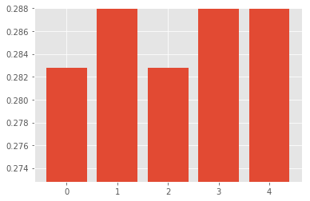

```python
plt.bar(range(len(per_fold_eval_criteria)),per_fold_eval_criteria)
plt.ylim([min(per_fold_eval_criteria)-0.01,max(per_fold_eval_criteria)])
```

### n_layers = 5

```python
%%time
# select model
nn = MultiLayerPerceptron(**params, n_layers=5)

# run model training and cross validation
per_fold_eval_criteria = cross_val_score(estimator=nn,
                                         X=X,
                                         y=y,
                                         cv=cv,
                                         scoring=score
                                        )
```

```
CPU times: user 3min 55s, sys: 16.2 s, total: 4min 11s
Wall time: 2min 6s
```

```python
for a in per_fold_eval_criteria:
    print(a)
print("\nMean:", np.mean(per_fold_eval_criteria))
```

```
0.2879829812496908
0.2879796155653959
0.2879796155653959
0.2879938645753445
0.28800811499542295

Mean: 0.28798883839025
```

```
(0.2779796155653959, 0.28800811499542295)
```

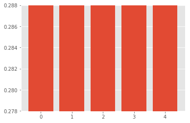

```python
plt.bar(range(len(per_fold_eval_criteria)),per_fold_eval_criteria)
plt.ylim([min(per_fold_eval_criteria)-0.01,max(per_fold_eval_criteria)])
```

### n_layers = 8

```python
%%time
# select model
nn = MultiLayerPerceptron(**params, n_layers=8)

# run model training and cross validation
per_fold_eval_criteria = cross_val_score(estimator=nn,
                                         X=X,
                                         y=y,
                                         cv=cv,
                                         scoring=score
                                        )
```

```
CPU times: user 7min 1s, sys: 41.5 s, total: 7min 42s
Wall time: 4min 11s
```

```python
for a in per_fold_eval_criteria:
    print(a)
print("\nMean:", np.mean(per_fold_eval_criteria))
```

```
0.2879829812496908
0.22368453603146723
0.2879796155653959
0.2879938645753445
0.2828372794972661

Mean: 0.27409565538383285
```

```
(0.21368453603146723, 0.2879938645753445)
```

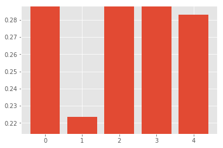

```python
plt.bar(range(len(per_fold_eval_criteria)),per_fold_eval_criteria)
plt.ylim([min(per_fold_eval_criteria)-0.01,max(per_fold_eval_criteria)])
```

According to the results above, choosing 5 as the number of hidden layers gives us a relatively better result.

Overall, choosing sigmoid as phi function, quadratic as objective function, and 5 as the number of hidden layers gives us a relatively better result.

## 3.3 magnitude of the gradients

```python
params = dict(n_hidden=10,
              n_layers=2,
              C=0.01, # tradeoff L2 regularizer
              epochs=20, # iterations
              eta=0.001,  # learning rate
              random_state=1,
              phi='sigmoid',
              cost='quadratic'
             )
```

```python
nn = MultiLayerPerceptron(**params)
nn.fit(X, y)

for i in range(3):
    print("Layer", i + 1, ":", nn.gradients_[i])
```

```
Layer 1 : [10.152887717240878, 0.00014550652038846127, 0.0001455050653232572, 0.00014550361027260408, 0.0001455021552365015, 0.00014550070021494905, 0.00014549924520794683, 0.00014549779021549476, 0.00014549633523759265, 0.00014549488027424027, 0.0001454934253254375, 0.00014549197039118432, 0.000145…
Layer 2 : [595.534571667793, 0.004824660930862714, 0.0048246126842534055, 0.004824564438126562, 0.00482451619248218, 0.004824467947320256, 0.004824419702640782, 0.004824371458443756, 0.004824323214729171, 0.004824274971497024, 0.004824226728747309, 0.004824178486480021, 0.004824130244695156, 0.00482…
Layer 3 : [20939.05932498237, 0.17292252253679188, 0.1729207933115665, 0.1729190641036334, 0.17291733491299235, 0.17291560573964324, 0.17291387658358584, 0.17291214744482, 0.17291041832334555, 0.1729086892191623, 0.1729069601322701, 0.1729052310626688, 0.17290350201035817, 0.17290177297533807, 0.172…
```

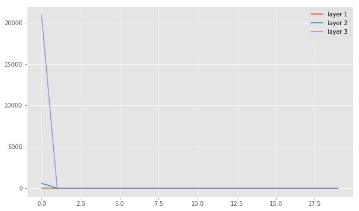

```python
plt.figure(figsize=(10, 6))

for i in range(3):
    plt.plot(np.arange(len(nn.gradients_[0])), nn.gradients_[i], label='layer {}'.format(i + 1))
plt.legend(loc='best')
plt.show()
```

The above plot shows the magnitude of the gradients in each layer of the neural network versus the training iteration. </br> After 1 iteration, the gradients stay consistent in each layer.

# 4. Exceptional Work

In order to implement two more phi functions: ReLU and SiLU (also called Swish), we need to update our MLP modeling in part 3.

```python
class MultiLayerPerceptronBase(object):
    def __init__(self, n_hidden=30, n_layers=1,
                 C=0.0, epochs=500, eta=0.001, random_state=None,
                 phi='sigmoid', cost='cross_entropy'):
        np.random.seed(random_state)
        self.n_hidden = n_hidden   # number of hidden units
        self.n_layers = n_layers   # number of hidden layers
        self.l2_C = C
        self.epochs = epochs
        self.eta = eta

        if phi in ['sigmoid', 'linear','relu','silu']:
            self.phi = phi
        else:
            raise ValueError('Invalid! This phi function has not yet been implemented.')

        if cost in ['quadratic', 'cross_entropy']:
            self.cost = cost
        else:
            raise ValueError('Invalid! This cost function has not yet been implemented.')

    @staticmethod
    def _encode_labels(y):
        """Encode labels into one-hot representation"""
        onehot = pd.get_dummies(y).values.T

        return onehot

    # Modified for multi-layer
    def _initialize_weights(self):
        """Initialize weights with small random numbers."""
        W = []

        bound = np.sqrt(6. / (self.n_hidden + self.n_features_ + 1))
        W_first = np.random.uniform(-bound, bound, (self.n_hidden, self.n_features_ + 1))
        W.append(W_first)

        for i in range(1, self.n_layers):
            bound = np.sqrt(6. / (self.n_hidden + self.n_hidden + 1))
            W_i = np.random.uniform(-bound, bound, (self.n_hidden, self.n_hidden + 1))
            W.append(W_i)

        bound = np.sqrt(0.5 / (self.n_hidden + self.n_output_ + 1))
        W_last = np.random.uniform(-bound, bound, (self.n_output_, self.n_hidden + 1))
        W.append(W_last)

        return W

    def _phi_function(self, z):
        if self.phi == 'sigmoid':         # implement sigmoid function
            """Use scipy.special.expit to avoid overflow"""
            # 1.0 / (1.0 + np.exp(-z))
            return expit(z)
        elif self.phi == 'linear':        # implement linear function
            return z
        elif self.phi == 'relu':
            return np.maximum(0,z.copy())
        elif self.phi == 'silu':
            return z * expit(z)

    @staticmethod
    def _add_bias_unit(X, how='column'):
        """Add bias unit (column or row of 1s) to array at index 0"""
        if how == 'column':
            ones = np.ones((X.shape[0], 1))
            X_new = np.hstack((ones, X))
        elif how == 'row':
            ones = np.ones((1, X.shape[1]))
            X_new = np.vstack((ones, X))
        return X_new

    # Modified for multi-layer
    @staticmethod
    def _L2_reg(lambda_, W):
        """Compute L2-regularization cost"""
        # only compute for non-bias terms
        result = 0
        for i in range(len(W)):
            result = result + np.mean(W[i][:, 1:] ** 2)
        return (lambda_/2.0) * np.sqrt(result)
        #return (lambda_/2.0) * np.sqrt(np.mean(W1[:, 1:] ** 2) + np.mean(W2[:, 1:] ** 2))

    # Modified for multi-layer
    def _cost(self, A, Y_enc, W):
        '''Get the objective function value'''
        if self.cost == 'quadratic':
            cost = np.mean((Y_enc - A) ** 2)
        elif self.cost == 'cross_entropy':
            cost = -np.mean(np.nan_to_num(Y_enc * np.log(A) + (1 - Y_enc) * np.log(1 - A)))

        L2_term = self._L2_reg(self.l2_C, W)
        return cost + L2_term
```

```python
class MultiLayerPerceptron(MultiLayerPerceptronBase):
    def _feedforward(self, X, W):
        """Compute feedforward step
        -----------
        X : Input layer with original features.
        W[0]: Weight matrix for input layer -> hidden layer.
        W[i]: Weight matrix for (i)th hidden layer -> (i+1)th hidden layer
        W[self.n_layers]: Weight matrix for hidden layer -> output layer.
        ----------
        A : activations into layer (or output layer)
        Z : layer inputs

        """
        A_list = []
        Z_list = []

        A = self._add_bias_unit(X, how='column').T
        A_list.append(A)

        for i in range(self.n_layers):
            Z = W[i] @ A
            A = self._add_bias_unit(self._phi_function(Z), how='row')
            Z_list.append(Z)
            A_list.append(A)

        Z = W[self.n_layers] @ A
        A = self._phi_function(Z)
        Z_list.append(Z)
        A_list.append(A)

        return A_list, Z_list   # len(A_list) = len(Z_list) + 1

    def _forward_grad(self, A):
        if self.phi == 'sigmoid':
            return A * (1 - A)
        elif self.phi == 'linear':
            return np.ones(A.shape)
        elif self.phi == 'relu':
            return np.ones(A.shape) * (A > 0)
        elif self.phi == 'silu':
            return expit(A) + A * expit(A) * (1 - expit(A))

    def _cost_grad(self, A, Y):
        if self.cost == 'quadratic':
            return -2 * (Y - A) * self._forward_grad(A)
        elif self.cost == 'cross_entropy':
            return (A - Y)

    def _get_gradient(self, A_list, Z_list, Y_enc, W):
        """Compute gradient step using backpropagation"""
        # vectorized backpropagation
        grad_list = W.copy()
        V = W.copy()

        V[-1] = self._cost_grad(A_list[-1], Y_enc)

        grad_list[-1] = V[-1] @ A_list[-2].T
        grad_list[-1][:,1:] += W[-1][:,1:] * self.l2_C

        # for each instance's activations
        for i in range(-2, -self.n_layers-2, -1):
            if i == -2:
                V[i] = (self._forward_grad(A_list[i]) * (W[i+1].T @ V[i+1]))
            else:
                V[i] = (self._forward_grad(A_list[i]) * (W[i+1].T @ V[i+1][1:,:]))

            grad_list[i] = V[i][1:,:] @ A_list[i-1].T

            # regularize weights that are not bias terms
            grad_list[i][:,1:] += W[i][:,1:] * self.l2_C

        return grad_list

    def predict(self, X):
        """Predict class labels"""
        A_list, _ = self._feedforward(X, self.W)
        y_pred = np.argmax(A_list[-1], axis=0)
        return y_pred

    def fit(self, X, y, print_progress=False):
        """Learn weights from training data"""

        X_data, y_data = X.copy(), y.copy()
        Y_enc = self._encode_labels(y)

        # init weights and setup matrices
        self.n_features_ = X_data.shape[1]
        self.n_output_ = Y_enc.shape[0]
        self.W = self._initialize_weights()

        self.cost_ = []
        self.gradients_ = []

        for i in range(len(self.W)):
            self.gradients_.append([])

        for i in range(self.epochs):

            if print_progress > 0 and (i + 1) % print_progress == 0:
                sys.stderr.write('\rEpoch: %d/%d' % (i + 1, self.epochs))
                sys.stderr.flush()

            # feedforward all instances
            A_list, Z_list = self._feedforward(X_data, self.W)

            cost = self._cost(A_list[-1], Y_enc, self.W)
            self.cost_.append(cost)

            # compute gradient via backpropagation
            grad_list = self._get_gradient(A_list, Z_list, Y_enc, self.W)

            for j in range(len(self.W)):
                self.W[j] -= self.eta * grad_list[j]
                self.gradients_[j].append(abs(np.mean(grad_list[j])))

        return self

    # make the estimator compliant with sklearn's API
    def get_params(self, deep=True):
        return {'n_hidden': self.n_hidden,
                'n_layers': self.n_layers,
                'C': self.l2_C,
                'epochs': self.epochs,
                'eta': self.eta,
                'phi': self.phi,
                'cost': self.cost
               }

    def set_params(self, **parameters):
        for parameter, value in parameters.items():
            self.__setattr__(parameter, value)
        return self
```

From the results in part 3, we get that when choosing sigmoid as phi function, quadratic as objective function, and 5 as the number of hidden layers gives us a relatively better result. So in exceptional work, we compare relu and silu to linear and sigmoid, set layers equal to 5, objective function equals to quadratic.

```python
params = dict(n_hidden=10,
              n_layers=5,
              C=0.01, # tradeoff L2 regularizer
              epochs=100, # iterations
              eta=0.001,  # learning rate
              random_state=1,
             )
```

```python
cv = StratifiedKFold(n_splits=5)
# select evaluation criteria
score = make_scorer(score_func=f1_score,
                    pos_label=1,
                    greater_is_better=True,
                    average='micro')

X = ddc.drop(labels=["pricerange"], axis="columns")
y = ddc.pricerange.values
```

### relu

```python
%%time
# select model
nn = MultiLayerPerceptron(**params, phi='relu', cost='quadratic')

# run model training and cross validation
per_fold_eval_criteria = cross_val_score(estimator=nn,
                                         X=X,
                                         y=y,
                                         cv=cv,
                                         scoring=score
                                        )
```

```
CPU times: user 3min 24s, sys: 17.4 s, total: 3min 42s
Wall time: 2min 9s
```

```python
for a in per_fold_eval_criteria:
    print(a)
print("\nMean:", np.mean(per_fold_eval_criteria))
```

```
0.28281304111215555
0.2828092917398511
0.2828092917398511
0.2828232849261523
0.2828372794972661

Mean: 0.2828184378030552
```

```python
plt.bar(range(len(per_fold_eval_criteria)),per_fold_eval_criteria)
plt.ylim([min(per_fold_eval_criteria)-0.01,max(per_fold_eval_criteria)])
```

[output not shown]

```
(0.2728092917398511, 0.2828372794972661)
```

### silu

```python
%%time
# select model
nn = MultiLayerPerceptron(**params, phi='silu', cost='quadratic')

# run model training and cross validation
per_fold_eval_criteria = cross_val_score(estimator=nn,
                                         X=X,
                                         y=y,
                                         cv=cv,
                                         scoring=score
                                        )
```

```
CPU times: user 5min 28s, sys: 25.3 s, total: 5min 53s
Wall time: 4min 26s
```

```python
for a in per_fold_eval_criteria:
    print(a)
print("\nMean:", np.mean(per_fold_eval_criteria))
```

```
0.28281304111215555
0.2828092917398511
0.2828092917398511
0.2828232849261523
0.2828372794972661

Mean: 0.2828184378030552
```

```python
plt.bar(range(len(per_fold_eval_criteria)),per_fold_eval_criteria)
plt.ylim([min(per_fold_eval_criteria)-0.01,max(per_fold_eval_criteria)])
```

[output not shown]

```
(0.2728092917398511, 0.2828372794972661)
```

According to the results from relu and silu, the results are the same, which is 0.2828184378030552. However, based on the time cost for these two different function, we can get that relu is better because relu is faster than silu. So we think when compare relu and silu, results for relu is better.

Then we compare relu with the best result is part 3. In part 3, we get that choosing sigmoid as phi function, quadratic as objective function, and 5 as the number of hidden layers gives us a relatively better result which is 0.28798883839025. And wall time for sigmoid is 2min6s which is little less than relu. Comparing these two results, we know that sigmoid function is better.

So we can get the final result that based on f1_score, when phi function = sigmoid, objective function = quadratic, layers = 5, we can get a better result.